# Resampling Methods

Module 08

Ray J. Hoobler

## Libraries

```r
library(tidyverse)
library(broom)
library(patchwork)
```

# Cross-Validation

## The Validation Set Approach

## The Validation Set Approach

### Auto MPG dataset (Quinlan 1993)

- 398 observations
- 9 variables
- Predict `mpg` using `horsepower`

```r
auto_mpg_column_names <- c("mpg", "cylinders", "displacement", "horsepower", "weight", "acceleration", "model_year", "origin", "car_name")

auto_mpg_spaces <- read_table("datasets/auto+mpg/auto-mpg.data", na = "?", col_names = auto_mpg_column_names[1:8])

auto_mpg_tab <- read_delim("datasets/auto+mpg/auto-mpg.data", delim = "\t", col_names = FALSE) |> select(2)

# auto_mpg_spaces
# auto_mpg_tab

auto_mpg_9 <- bind_cols(auto_mpg_spaces, auto_mpg_tab) |>
  set_names(auto_mpg_column_names)

summary(auto_mpg_9)
```

```
      mpg          cylinders      displacement     horsepower        weight
 Min.   : 9.00   Min.   :3.000   Min.   : 68.0   Min.   : 46.0   Min.   :1613
 1st Qu.:17.50   1st Qu.:4.000   1st Qu.:104.2   1st Qu.: 75.0   1st Qu.:2224
 Median :23.00   Median :4.000   Median :148.5   Median : 93.5   Median :2804
 Mean   :23.51   Mean   :5.455   Mean   :193.4   Mean   :104.5   Mean   :2970
 3rd Qu.:29.00   3rd Qu.:8.000   3rd Qu.:262.0   3rd Qu.:126.0   3rd Qu.:3608
 Max.   :46.60   Max.   :8.000   Max.   :455.0   Max.   :230.0   Max.   :5140
                                                 NA's   :6
  acceleration     model_year        origin        car_name
 Min.   : 8.00   Min.   :70.00   Min.   :1.000   Length:398
 1st Qu.:13.82   1st Qu.:73.00   1st Qu.:1.000   Class :character
 Median :15.50   Median :76.00   Median :1.000   Mode  :character
 Mean   :15.57   Mean   :76.01   Mean   :1.573
 3rd Qu.:17.18   3rd Qu.:79.00   3rd Qu.:2.000
 Max.   :24.80   Max.   :82.00   Max.   :3.000
```

```r
# there are 6 NA values in the horsepower column

auto_mpg_9_final <- auto_mpg_9 |>
  drop_na(horsepower)

summary(auto_mpg_9_final)
```

```
      mpg          cylinders      displacement     horsepower        weight
 Min.   : 9.00   Min.   :3.000   Min.   : 68.0   Min.   : 46.0   Min.   :1613
 1st Qu.:17.00   1st Qu.:4.000   1st Qu.:105.0   1st Qu.: 75.0   1st Qu.:2225
 Median :22.75   Median :4.000   Median :151.0   Median : 93.5   Median :2804
 Mean   :23.45   Mean   :5.472   Mean   :194.4   Mean   :104.5   Mean   :2978
 3rd Qu.:29.00   3rd Qu.:8.000   3rd Qu.:275.8   3rd Qu.:126.0   3rd Qu.:3615
 Max.   :46.60   Max.   :8.000   Max.   :455.0   Max.   :230.0   Max.   :5140
  acceleration     model_year        origin        car_name
 Min.   : 8.00   Min.   :70.00   Min.   :1.000   Length:392
 1st Qu.:13.78   1st Qu.:73.00   1st Qu.:1.000   Class :character
 Median :15.50   Median :76.00   Median :1.000   Mode  :character
 Mean   :15.54   Mean   :75.98   Mean   :1.577
 3rd Qu.:17.02   3rd Qu.:79.00   3rd Qu.:2.000
 Max.   :24.80   Max.   :82.00   Max.   :3.000
```

## Plot of the data

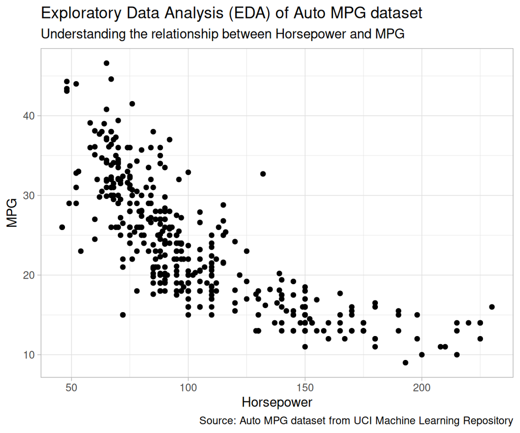

```r
auto_mpg_9_final |>
  ggplot(aes(x = horsepower, y = mpg)) +
  geom_point() +
  labs(
    title = "Auto MPG Dataset",
    x = "Horsepower",
    y = "MPG"
  ) +
  labs(
    title = "Exploratory Data Analysis (EDA) of Auto MPG dataset",
    subtitle = "Understanding the relationship between Horsepower and MPG",
    x = "Horsepower",
    y = "MPG",
    caption = "Source: Auto MPG dataset from UCI Machine Learning Repository"
  ) +
  theme_light()
```

## Example: Validation Set Approach (1/20)

### Random 50% test train split of the data

```r
set.seed(42)
# Create a random 50% split of the data index using the response variable mpg

auto_mpg_train <- caret::createDataPartition(auto_mpg_9_final$mpg, p = 0.5, list = FALSE)
head(auto_mpg_train, 10)
```

```
      Resample1
 [1,]         1
 [2,]         3
 [3,]         4
 [4,]         5
 [5,]         6
 [6,]         7
 [7,]         8
 [8,]        10
 [9,]        12
[10,]        18
```

## Example: Validation Set Approach (2/20)

### Random 50% test train split of the data

```r
auto_mpg_train_data <- auto_mpg_9_final[auto_mpg_train,]
auto_mpg_test_data <- auto_mpg_9_final[-auto_mpg_train,]

auto_mpg_train_data
```

| mpg | cylinders | displacement | horsepower | weight | acceleration | model_year | origin | car_name |
| --- | --- | --- | --- | --- | --- | --- | --- | --- |
| 18.0 | 8 | 307 | 130 | 3504 | 12.0 | 70 | 1 | chevrolet chevelle malibu |
| 18.0 | 8 | 318 | 150 | 3436 | 11.0 | 70 | 1 | plymouth satellite |
| 16.0 | 8 | 304 | 150 | 3433 | 12.0 | 70 | 1 | amc rebel sst |
| 17.0 | 8 | 302 | 140 | 3449 | 10.5 | 70 | 1 | ford torino |
| 15.0 | 8 | 429 | 198 | 4341 | 10.0 | 70 | 1 | ford galaxie 500 |
| 14.0 | 8 | 454 | 220 | 4354 | 9.0 | 70 | 1 | chevrolet impala |
| 14.0 | 8 | 440 | 215 | 4312 | 8.5 | 70 | 1 | plymouth fury iii |
| 15.0 | 8 | 390 | 190 | 3850 | 8.5 | 70 | 1 | amc ambassador dpl |
| 14.0 | 8 | 340 | 160 | 3609 | 8.0 | 70 | 1 | plymouth 'cuda 340 |
| 21.0 | 6 | 200 | 85 | 2587 | 16.0 | 70 | 1 | ford maverick |

[output cut: 188 more lines]

```r
auto_mpg_test_data
```

| mpg | cylinders | displacement | horsepower | weight | acceleration | model_year | origin | car_name |
| --- | --- | --- | --- | --- | --- | --- | --- | --- |
| 15.0 | 8 | 350.0 | 165 | 3693 | 11.5 | 70 | 1 | buick skylark 320 |
| 14.0 | 8 | 455.0 | 225 | 4425 | 10.0 | 70 | 1 | pontiac catalina |
| 15.0 | 8 | 383.0 | 170 | 3563 | 10.0 | 70 | 1 | dodge challenger se |
| 15.0 | 8 | 400.0 | 150 | 3761 | 9.5 | 70 | 1 | chevrolet monte carlo |
| 14.0 | 8 | 455.0 | 225 | 3086 | 10.0 | 70 | 1 | buick estate wagon (sw) |
| 24.0 | 4 | 113.0 | 95 | 2372 | 15.0 | 70 | 3 | toyota corona mark ii |
| 22.0 | 6 | 198.0 | 95 | 2833 | 15.5 | 70 | 1 | plymouth duster |
| 18.0 | 6 | 199.0 | 97 | 2774 | 15.5 | 70 | 1 | amc hornet |
| 27.0 | 4 | 97.0 | 88 | 2130 | 14.5 | 70 | 3 | datsun pl510 |
| 26.0 | 4 | 97.0 | 46 | 1835 | 20.5 | 70 | 2 | volkswagen 1131 deluxe sedan |

[output cut: 184 more lines]

## Example: Validation Set Approach (3/20)

### Fit a linear model on the training data

```r
auto_mpg_lm <- lm(mpg ~ horsepower, data = auto_mpg_train_data)
summary(auto_mpg_lm)
```

```
Call:
lm(formula = mpg ~ horsepower, data = auto_mpg_train_data)

Residuals:
     Min       1Q   Median       3Q      Max
-13.5314  -3.4708  -0.0281   2.5311  12.2426

Coefficients:
             Estimate Std. Error t value Pr(>|t|)
(Intercept) 40.144797   0.949810   42.27   <2e-16 ***
horsepower  -0.161297   0.008591  -18.77   <2e-16 ***
---
Signif. codes:  0 '***' 0.001 '**' 0.01 '*' 0.05 '.' 0.1 ' ' 1

Residual standard error: 4.602 on 196 degrees of freedom
Multiple R-squared:  0.6427,    Adjusted R-squared:  0.6408
F-statistic: 352.5 on 1 and 196 DF,  p-value: < 2.2e-16
```

## Example: Validation Set Approach (4/20)

### Predict the test data

```r
auto_mpg_test_pred <- predict(auto_mpg_lm, newdata = auto_mpg_test_data)
auto_mpg_test_pred
```

```
        1         2         3         4         5         6         7         8
13.530841  3.853039 12.724358 15.950292  3.853039 24.821610 24.821610 24.499017
        9        10        11        12        13        14        15        16
25.950687 32.725149 26.111984 21.918270 25.628094  5.466006  7.885456  9.014533
       17        18        19        20        21        22        23        24
25.950687 25.628094 24.015127 23.208643 25.950687 13.530841 11.111390 22.402160
       25        26        27        28        29        30        31        32
28.531435 24.015127 26.273281 29.015325 30.466995 27.241061 31.434775 26.273281
       33        34        35        36        37        38        39        40
15.950292 15.466402  6.595083 15.143808 14.337325 15.950292 26.111984 29.015325
       41        42        43        44        45        46        47        48
26.273281 25.305501 24.499017 27.241061 25.950687 11.917874  8.208050 15.950292
       49        50        51        52        53        54        55        56
14.659918  5.466006 24.015127 24.015127 25.950687 24.821610 11.111390 24.982907
       57        58        59        60        61        62        63        64
25.628094 22.886050 16.756775  3.046555 25.466797 24.821610 24.015127 29.337918
       65        66        67        68        69        70        71        72
27.241061 28.047544 22.402160 23.208643 17.563259 15.950292 15.950292 28.047544
       73        74        75        76        77        78        79        80
24.821610 28.531435 12.724358 15.950292 16.272885 23.208643 22.402160 24.821610
       81        82        83        84        85        86        87        88
22.402160 19.337522 28.047544 26.757171 24.499017 25.628094 24.821610 24.337720
       89        90        91        92        93        94        95        96
21.595676 27.079764 25.305501 27.402358 26.757171 17.563259 15.950292 24.015127
       97        98        99       100       101       102       103       104
23.208643 27.079764 31.757369 31.596072 24.015127 22.402160 28.047544 15.950292
      105       106       107       108       109       110       111       112
16.756775 19.176226 29.176621 16.756775 23.208643 24.337720 11.111390 12.724358
      113       114       115       116       117       118       119       120
16.111588 25.789391 26.757171 29.337918 27.563654 24.499017 22.402160 22.402160
      121       122       123       124       125       126       127       128
32.402556 29.499215 31.757369 30.466995 22.402160 17.563259 25.628094 26.434577
      129       130       131       132       133       134       135       136
22.402160 16.756775 17.724555 17.563259 24.499017 24.821610 26.434577 24.499017
      137       138       139       140       141       142       143       144
21.595676 28.692731 26.434577 25.628094 19.176226 17.885852 18.369742 15.143808
      145       146       147       148       149       150       151       152
29.660512 27.724951 28.692731 25.628094 28.854028 28.854028 29.660512 25.628094
      153       154       155       156       157       158       159       160
21.595676 21.595676 25.628094 27.886248 30.466995 29.660512 25.628094 25.628094
      161       162       163       164       165       166       167       168
28.047544 25.305501 29.660512 32.402556 29.337918 29.337918 18.853632 24.015127
      169       170       171       172       173       174       175       176
25.950687 26.595874 22.402160 29.337918 30.144402 29.176621 29.983105 29.660512
      177       178       179       180       181       182       183       184
29.660512 28.047544 24.015127 27.886248 21.434380 20.789193 26.434577 25.950687
      185       186       187       188       189       190       191       192
26.434577 28.208841 29.176621 28.854028 29.337918 25.305501 24.660314 26.595874
      193       194
25.628094 26.918468
```

## Example: Validation Set Approach (5/20)

### Calculate the MSE

```r
mpg_mse_lm <- mean((auto_mpg_test_data$mpg - auto_mpg_test_pred)^2)
mpg_mse_lm
```

```
[1] 27.06624
```

## Example: Validation Set Approach (6/20)

### Repeat the process for a quadratic model

```r
auto_mpg_lm_quad <- lm(mpg ~ horsepower + I(horsepower^2), data = auto_mpg_train_data)
summary(auto_mpg_lm_quad)
```

```
Call:
lm(formula = mpg ~ horsepower + I(horsepower^2), data = auto_mpg_train_data)

Residuals:
     Min       1Q   Median       3Q      Max
-14.5789  -2.2724  -0.0706   2.2250  12.0560

Coefficients:
                  Estimate Std. Error t value Pr(>|t|)
(Intercept)     57.8265703  2.3769451  24.328  < 2e-16 ***
horsepower      -0.4878086  0.0418201 -11.664  < 2e-16 ***
I(horsepower^2)  0.0013261  0.0001671   7.936  1.6e-13 ***
---
Signif. codes:  0 '***' 0.001 '**' 0.01 '*' 0.05 '.' 0.1 ' ' 1

Residual standard error: 4.011 on 195 degrees of freedom
Multiple R-squared:  0.7299,    Adjusted R-squared:  0.7271
F-statistic: 263.5 on 2 and 195 DF,  p-value: < 2.2e-16
```

## Example: Validation Set Approach (7/20)

### Predict the test data of the quadratic model

```r
auto_mpg_test_pred_quad <- predict(auto_mpg_lm_quad, newdata = auto_mpg_test_data)
auto_mpg_test_pred_quad
```

```
       1        2        3        4        5        6        7        8
13.44171 15.20435 13.22392 14.49293 15.20435 23.45297 23.45297 22.98658
       9       10       11       12       13       14       15       16
25.16887 38.19344 25.42461 19.63740 24.66535 14.24752 13.30957 13.07608
      17       18       19       20       21       22       23       24
25.16887 24.66535 22.30689 21.22712 25.16887 13.44171 12.98724 20.21365
      25       26       27       28       29       30       31       32
29.57895 22.30689 25.68300 30.48143 33.33208 27.28904 35.35187 25.68300
      33       34       35       36       37       38       39       40
14.49293 14.23495 13.73554 14.07622 13.72581 14.49293 25.42461 30.48143
      41       42       43       44       45       46       47       48
25.68300 24.17244 22.98658 27.28904 25.16887 13.07243 13.22959 14.49293
      49       50       51       52       53       54       55       56
13.85802 14.24752 22.30689 22.30689 25.16887 23.45297 12.98724 23.69014
      57       58       59       60       61       62       63       64
24.66535 20.81378 14.97595 15.78223 24.41757 23.45297 22.30689 31.09634
      65       66       67       68       69       70       71       72
27.28904 28.70034 20.21365 21.22712 15.52528 14.49293 14.49293 28.70034
      73       74       75       76       77       78       79       80
23.45297 29.57895 13.22392 14.49293 14.67818 21.22712 20.21365 23.45297
      81       82       83       84       85       86       87       88
20.21365 16.96719 28.70034 26.47408 22.98658 24.66535 23.45297 22.75737
      89       90       91       92       93       94       95       96
19.26649 27.01474 24.17244 27.56599 26.47408 15.52528 14.49293 22.30689
      97       98       99      100      101      102      103      104
21.22712 27.01474 36.04635 35.69778 22.30689 20.21365 28.70034 14.49293
     105      106      107      108      109      110      111      112
14.97595 16.82285 30.78756 14.97595 21.22712 22.75737 12.98724 13.22392
     113      114      115      116      117      118      119      120
14.58423 24.91579 26.47408 31.09634 27.84560 22.98658 20.21365 20.21365
     121      122      123      124      125      126      127      128
37.46713 31.40777 36.04635 33.33208 20.21365 15.52528 24.66535 25.94404
     129      130      131      132      133      134      135      136
20.21365 14.97595 15.64310 15.52528 22.98658 23.45297 25.94404 22.98658
     137      138      139      140      141      142      143      144
19.26649 29.87712 25.94404 24.66535 16.82285 15.76357 16.14091 14.07622
     145      146      147      148      149      150      151      152
31.72186 28.12786 29.87712 24.66535 30.17795 30.17795 31.72186 24.66535
     153      154      155      156      157      158      159      160
19.26649 19.26649 24.66535 28.41278 33.33208 31.72186 24.66535 24.66535
     161      162      163      164      165      166      167      168
28.70034 24.17244 31.72186 37.46713 31.09634 31.09634 16.54211 22.30689
     169      170      171      172      173      174      175      176
25.16887 26.20774 20.21365 31.09634 32.68004 30.78756 32.35799 31.72186
     177      178      179      180      181      182      183      184
31.72186 28.70034 22.30689 28.41278 19.08502 18.38564 25.94404 25.16887
     185      186      187      188      189      190      191      192
25.94404 28.99056 30.78756 30.17795 31.09634 24.17244 23.21845 26.20774
     193      194
24.66535 26.74308
```

## Example: Validation Set Approach (8/20)

### Calculate the MSE of the quadratic model

```r
mpg_mse_quad <- mean((auto_mpg_test_data$mpg - auto_mpg_test_pred_quad)^2)
mpg_mse_quad
```

```
[1] 22.30821
```

## Example: Validation Set Approach (9/20)

### Repeat the process for a cubic model

```r
auto_mpg_lm_cubic <- lm(mpg ~ horsepower + I(horsepower^2) + I(horsepower^3), data = auto_mpg_train_data)
summary(auto_mpg_lm_cubic)
```

```
Call:
lm(formula = mpg ~ horsepower + I(horsepower^2) + I(horsepower^3),
    data = auto_mpg_train_data)

Residuals:
     Min       1Q   Median       3Q      Max
-14.5616  -2.1686  -0.0387   2.2816  12.1906

Coefficients:
                  Estimate Std. Error t value Pr(>|t|)
(Intercept)      6.169e+01  6.106e+00  10.103  < 2e-16 ***
horsepower      -5.936e-01  1.596e-01  -3.719 0.000261 ***
I(horsepower^2)  2.211e-03  1.298e-03   1.703 0.090240 .
I(horsepower^3) -2.272e-06  3.307e-06  -0.687 0.492869
---
Signif. codes:  0 '***' 0.001 '**' 0.01 '*' 0.05 '.' 0.1 ' ' 1

Residual standard error: 4.017 on 194 degrees of freedom
Multiple R-squared:  0.7306,    Adjusted R-squared:  0.7264
F-statistic: 175.3 on 3 and 194 DF,  p-value: < 2.2e-16
```

## Example: Validation Set Approach (10/20)

### Predict the test data of the cubic model

```r
auto_mpg_test_pred_cubic <- predict(auto_mpg_lm_cubic, newdata = auto_mpg_test_data)
auto_mpg_test_pred_cubic
```

```
       1        2        3        4        5        6        7        8
13.72427 14.16573 13.50298 14.72080 14.16573 23.29990 23.29990 22.83595
       9       10       11       12       13       14       15       16
25.02291 38.84003 25.28183 19.56152 24.51471 13.67405 13.22028 13.13625
      17       18       19       20       21       22       23       24
25.02291 24.51471 22.16324 21.10305 25.02291 13.72427 13.21651 20.11761
      25       26       27       28       29       30       31       32
29.56159 22.16324 25.54399 30.50895 33.54048 27.18566 35.72305 25.54399
      33       34       35       36       37       38       39       40
14.72080 14.48018 13.41775 14.33147 13.99987 14.72080 25.28183 30.50895
      41       42       43       44       45       46       47       48
25.54399 24.01930 22.83595 27.18566 25.02291 13.33430 13.18759 14.72080
      49       50       51       52       53       54       55       56
14.12569 13.67405 22.16324 22.16324 25.02291 23.29990 13.21651 23.53655
      57       58       59       60       61       62       63       64
24.51471 20.69999 15.16954 14.46322 24.26542 23.29990 22.16324 31.15791
      65       66       67       68       69       70       71       72
27.18566 28.64519 20.11761 21.10305 15.67940 14.72080 14.72080 28.64519
      73       74       75       76       77       78       79       80
23.29990 29.56159 13.50298 14.72080 14.89307 21.10305 20.11761 23.29990
      81       82       83       84       85       86       87       88
20.11761 17.02466 28.64519 26.35002 22.83595 24.51471 23.29990 22.60863
      89       90       91       92       93       94       95       96
19.20522 26.90380 24.01930 27.47085 26.35002 15.67940 14.72080 22.16324
      97       98       99      100      101      102      103      104
21.10305 26.90380 36.47991 36.09963 22.16324 20.11761 28.64519 14.72080
     105      106      107      108      109      110      111      112
15.16954 16.88932 30.83168 15.16954 21.10305 22.60863 13.21651 13.50298
     113      114      115      116      117      118      119      120
14.80574 24.76721 26.35002 31.15791 27.75938 22.83595 20.11761 20.11761
     121      122      123      124      125      126      127      128
38.03829 31.48764 36.47991 33.54048 20.11761 15.67940 24.51471 25.80940
     129      130      131      132      133      134      135      136
20.11761 15.16954 15.78886 15.67940 22.83595 23.29990 25.80940 22.83595
     137      138      139      140      141      142      143      144
19.20522 29.87392 25.80940 24.51471 16.88932 15.90085 16.25210 14.33147
     145      146      147      148      149      150      151      152
31.82089 28.05127 29.87392 24.51471 30.18970 30.18970 31.82089 24.51471
     153      154      155      156      157      158      159      160
19.20522 19.20522 24.51471 28.34654 33.54048 31.82089 24.51471 24.51471
     161      162      163      164      165      166      167      168
28.64519 24.01930 31.82089 38.03829 31.15791 31.15791 16.62658 22.16324
     169      170      171      172      173      174      175      176
25.02291 26.07807 20.11761 31.15791 32.84193 30.83168 32.49803 31.82089
     177      178      179      180      181      182      183      184
31.82089 28.64519 22.16324 28.34654 19.03136 18.36418 25.80940 25.02291
     185      186      187      188      189      190      191      192
25.80940 28.94724 30.83168 30.18970 31.15791 24.01930 23.06637 26.07807
     193      194
24.51471 26.62526
```

## Example: Validation Set Approach (11/20)

### Calculate the MSE of the cubic model

```r
mpg_mse_cubic <- mean((auto_mpg_test_data$mpg - auto_mpg_test_pred_cubic)^2)
mpg_mse_cubic
```

```
[1] 22.25234
```

## Example: Validation Set Approach (12/20)

### Compare the MSE of the models

```r
# Create a data frame of the MSE values
mpg_mse_df <- tibble(
  Model = c("Linear", "Quadratic", "Cubic"),
  MSE = round(c(mpg_mse_lm, mpg_mse_quad, mpg_mse_cubic), 2)
)

mpg_mse_df |>
  gt::gt()
```

| Model | MSE |
| --- | --- |
| Linear | 27.07 |
| Quadratic | 22.31 |
| Cubic | 22.25 |

# DRY (Don’t Repeat Yourself)

## Example: Validation Set Approach (13/20)

### Use the poly() function and use a for loop

```r
# Create a for loop to fit the models and calculate the MSE
mpg_model_order <- c()
mpg_mse <- c()

for (i in 1:6) {
  auto_mpg_lm <- lm(mpg ~ poly(horsepower, i), data = auto_mpg_train_data)
  auto_mpg_test_pred <- predict(auto_mpg_lm, newdata = auto_mpg_test_data)
  mpg_model_order[i] <- i
  mpg_mse[i] <- mean((auto_mpg_test_data$mpg - auto_mpg_test_pred)^2)
}

mpg_model_dry_df <- tibble(
  model_order = mpg_model_order,
  mpg_mse
)

mpg_model_dry_df
```

| model_order | mpg_mse |
| --- | --- |
| 1 | 27.06624 |
| 2 | 22.30821 |
| 3 | 22.25234 |
| 4 | 22.54065 |
| 5 | 21.83796 |
| 6 | 22.04073 |

## Example: Validation Set Approach (14/20

### Plot the MSE values

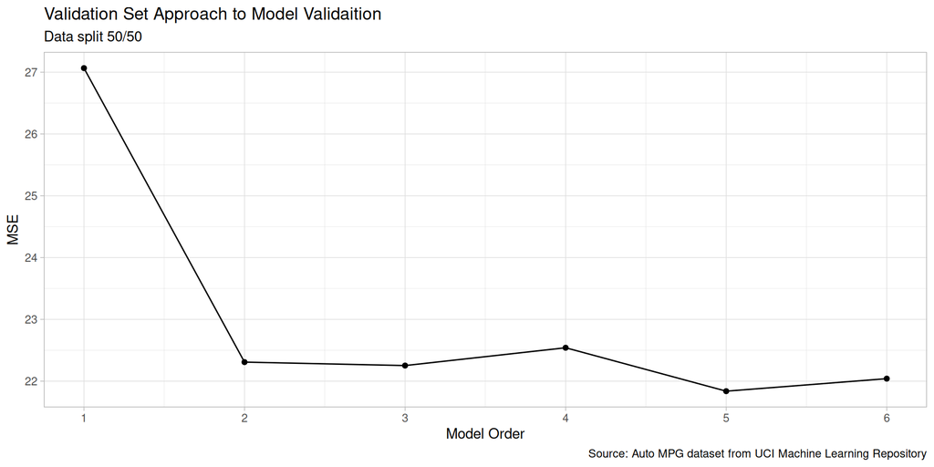

```r
mpg_model_dry_df |>
  ggplot(aes(x = model_order, y = mpg_mse)) +
  geom_point() +
  geom_line() +
  labs(
    title = "MSE vs. Model Order",
    x = "Model Order",
    y = "MSE"
  ) +
  labs(
    title = "Validation Set Approach to Model Validaition",
    subtitle = "Data split 50/50",
    x = "Model Order",
    y = "MSE",
    caption = "Source: Auto MPG dataset from UCI Machine Learning Repository"
  ) +
  scale_x_continuous(breaks = 1:6) +
  theme_light()
```

## Example: Validation Set Approach (15/20)

### How does MSE vary with our choice of the “random seed” used to split the data?

```r
mse_seed <- function(seed_values) {
  mse_values <- numeric(length(seed_values))

  for (i in seq_along(seed_values)) {
    set.seed(seed_values[i])

    auto_mpg_train <- caret::createDataPartition(auto_mpg_9_final$mpg, p = 0.5, list = FALSE)
    auto_mpg_train_data <- auto_mpg_9_final[auto_mpg_train,]
    auto_mpg_test_data <- auto_mpg_9_final[-auto_mpg_train,]

    auto_mpg_lm <- lm(mpg ~ horsepower, data = auto_mpg_train_data)
    auto_mpg_test_pred <- predict(auto_mpg_lm, newdata = auto_mpg_test_data)

    mse_values[i] <- mean((auto_mpg_test_data$mpg - auto_mpg_test_pred)^2)
  }

  result <- tibble::tibble(Seed = seed_values, MSE = round(mse_values, 3))
  return(result)
}

# Example usage:
seed_values <- c(42, sample(1:9999, 9))
result <- mse_seed(seed_values)
result
```

| Seed | MSE |
| --- | --- |
| 42 | 27.066 |
| 3734 | 24.012 |
| 7066 | 25.903 |
| 6100 | 25.078 |
| 3071 | 22.323 |
| 9901 | 24.481 |
| 9423 | 24.307 |
| 9301 | 25.705 |
| 1954 | 21.857 |
| 4249 | 25.646 |

## Example: Validation Set Approach (16/20)

### Calculate the MSE values for different seeds and model orders

```r
mse_seed_poly <- function(seed_values, max_degree = 3) {
  results <- tibble()

  for (seed in seed_values) {
    set.seed(seed)

    auto_mpg_train <- caret::createDataPartition(auto_mpg_9_final$mpg, p = 0.5, list = FALSE)
    auto_mpg_train_data <- auto_mpg_9_final[auto_mpg_train,]
    auto_mpg_test_data <- auto_mpg_9_final[-auto_mpg_train,]

    for (degree in 1:max_degree) {
      formula <- as.formula(paste("mpg ~ poly(horsepower, degree =", degree, ")"))
      auto_mpg_lm <- lm(formula, data = auto_mpg_train_data)
      auto_mpg_test_pred <- predict(auto_mpg_lm, newdata = auto_mpg_test_data)

      mse <- mean((auto_mpg_test_data$mpg - auto_mpg_test_pred)^2)

      results <- rbind(results, data.frame(Seed = seed, Degree = degree, MSE = mse))
    }
  }

  return(results)
}

# Example usage:
set.seed(42)  # Set a seed for reproducibility
seed_values <- c(42, sample(1:9999, 10))
result_df <- mse_seed_poly(seed_values, max_degree = 6)

result_df
```

| Seed | Degree | MSE |
| --- | --- | --- |
| 42 | 1 | 27.06624 |
| 42 | 2 | 22.30821 |
| 42 | 3 | 22.25234 |
| 42 | 4 | 22.54065 |
| 42 | 5 | 21.83796 |
| 42 | 6 | 22.04073 |
| 2369 | 1 | 24.42674 |
| 2369 | 2 | 21.32455 |
| 2369 | 3 | 21.97517 |
| 2369 | 4 | 22.25545 |

[output cut: 56 more lines]

### Plot the MSE values for different seeds

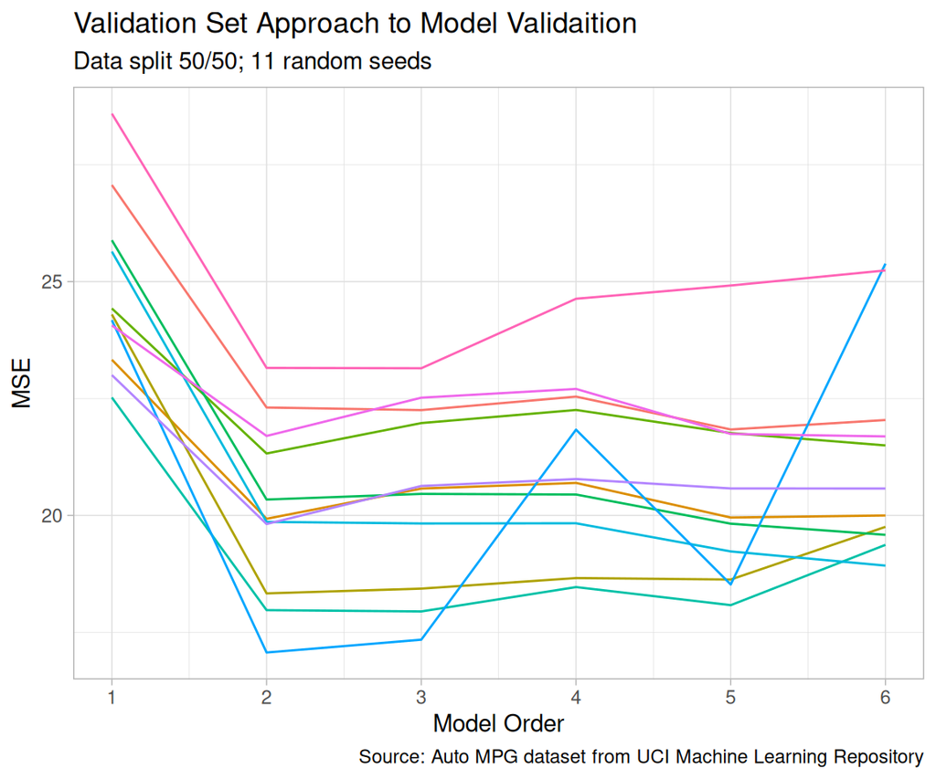

```r
result_df |>
  ggplot(aes(x = Degree, y = MSE, color = factor(Seed))) +
  geom_line(show.legend = FALSE) +
  labs(
    title = "MSE vs. Model Order",
    x = "Model Order",
    y = "MSE"
  ) +
  labs(
    title = "Validation Set Approach to Model Validaition",
    subtitle = "Data split 50/50; 11 random seeds",
    x = "Model Order",
    y = "MSE",
    caption = "Source: Auto MPG dataset from UCI Machine Learning Repository"
  ) +
  scale_x_continuous(breaks = 1:6) +
  theme_light()
```

## Example: Validation Set Approach (17/20)

### Mean values for the MSE

```r
result_df |>
  group_by(Degree) |>
  summarise(MSE = mean(MSE))
```

| Degree | MSE |
| --- | --- |
| 1 | 24.81885 |
| 2 | 20.16430 |
| 3 | 20.46447 |
| 4 | 21.16814 |
| 5 | 20.46134 |
| 6 | 21.27847 |

## Example: Validation Set Approach (18/20)

### Plot the predicted values versus the actual values for order 2

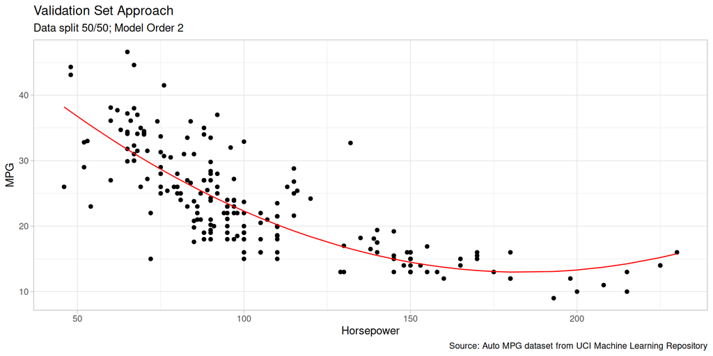

```r
auto_mpg_lm <- lm(mpg ~ poly(horsepower, 2), data = auto_mpg_train_data)
auto_mpg_test_pred <- predict(auto_mpg_lm, newdata = auto_mpg_test_data)

auto_mpg_test_data |>
  ggplot(aes(x = horsepower, y = mpg)) +
  geom_point() +
  geom_line(aes(y = auto_mpg_test_pred), color = "red") +
  labs(
    title = "Predicted vs. Actual Values",
    x = "Horsepower",
    y = "MPG"
  ) +
  labs(
    title = "Validation Set Approach",
    subtitle = "Data split 50/50; Model Order 2",
    x = "Horsepower",
    y = "MPG",
    caption = "Source: Auto MPG dataset from UCI Machine Learning Repository"
  ) +
  theme_light()
```

## Example: Validation Set Approach (19/20)

```r
# auto_mpg_poisson <- glm(mpg ~ horsepower, data = auto_mpg_train_data, family = "poisson")
# auto_mpg_test_pred_poisson <- predict(auto_mpg_poisson, newdata = auto_mpg_test_data, type = "response")

auto_mpg_gamma <- glm(mpg ~ horsepower, data = auto_mpg_train_data, family = Gamma(link = "log"))
auto_mpg_test_pred_gamma <- predict(auto_mpg_gamma, newdata = auto_mpg_test_data, type = "response")

# mpg_mse_poisson <- mean((auto_mpg_test_data$mpg - auto_mpg_test_pred_poisson)^2)
# mpg_mse_poisson

mpg_mse_gamma <- mean((auto_mpg_test_data$mpg - auto_mpg_test_pred_gamma)^2)
mpg_mse_gamma
```

```
[1] 23.80739
```

## Example: Validation Set Approach (20/20)

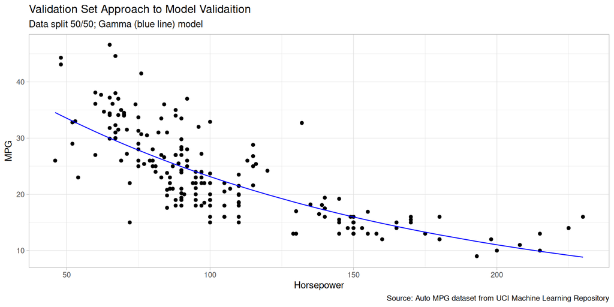

```r
auto_mpg_test_data |>
  ggplot(aes(x = horsepower, y = mpg)) +
  geom_point() +
  geom_line(aes(y = auto_mpg_test_pred_gamma), color = "blue") +
  labs(
    title = "Predicted vs. Actual Values",
    x = "Horsepower",
    y = "MPG"
  ) +
  labs(
    title = "Validation Set Approach to Model Validaition",
    subtitle = "Data split 50/50; Gamma (blue line) model",
    x = "Horsepower",
    y = "MPG",
    caption = "Source: Auto MPG dataset from UCI Machine Learning Repository"
  ) +
  theme_light()
```

# Cross-Validation Alternatives

## For Modest Datasets

[figure not shown]

## Example: Leave-One-Out Cross-Validation (LOOCV) (1/4)

### Fit a linear model using glm()

```r
auto_mpg_glm <- glm(mpg ~ horsepower, data = auto_mpg_9_final)
summary(auto_mpg_glm)
```

```
Call:
glm(formula = mpg ~ horsepower, data = auto_mpg_9_final)

Coefficients:
             Estimate Std. Error t value Pr(>|t|)
(Intercept) 39.935861   0.717499   55.66   <2e-16 ***
horsepower  -0.157845   0.006446  -24.49   <2e-16 ***
---
Signif. codes:  0 '***' 0.001 '**' 0.01 '*' 0.05 '.' 0.1 ' ' 1

(Dispersion parameter for gaussian family taken to be 24.06645)

    Null deviance: 23819.0  on 391  degrees of freedom
Residual deviance:  9385.9  on 390  degrees of freedom
AIC: 2363.3

Number of Fisher Scoring iterations: 2
```

### Fit a linear model using lm()

```r
auto_mpg_lm <- lm(mpg ~ horsepower, data = auto_mpg_9_final)
summary(auto_mpg_lm)
```

```
Call:
lm(formula = mpg ~ horsepower, data = auto_mpg_9_final)

Residuals:
     Min       1Q   Median       3Q      Max
-13.5710  -3.2592  -0.3435   2.7630  16.9240

Coefficients:
             Estimate Std. Error t value Pr(>|t|)
(Intercept) 39.935861   0.717499   55.66   <2e-16 ***
horsepower  -0.157845   0.006446  -24.49   <2e-16 ***
---
Signif. codes:  0 '***' 0.001 '**' 0.01 '*' 0.05 '.' 0.1 ' ' 1

Residual standard error: 4.906 on 390 degrees of freedom
Multiple R-squared:  0.6059,    Adjusted R-squared:  0.6049
F-statistic: 599.7 on 1 and 390 DF,  p-value: < 2.2e-16
```

WE perform linear regression using the `glm()` function rather than the `lm()` function because the former can be used together with `cv.glm()`. The `cv.glm()` function is part of the `boot` library (functions for bootstrapping).

## Example: Leave-One-Out Cross-Validation (LOOCV) (2/4)

### Perform LOOCV using the `cv.glm()` function

```r
library(boot)

auto_mpg_cv_glm <- cv.glm(auto_mpg_9_final, auto_mpg_glm, K = nrow(auto_mpg_9_final))
auto_mpg_cv_glm$delta
```

```
[1] 24.23151 24.23114
```

### LOOCV estimate for the test MSE

$$CV_{(n)} = \frac{1}{n} \sum_{i=1}^{n} \text{MSE}_i$$

## Example: Leave-One-Out Cross Validation (LOOCV) (3/4)

LOOCV is a general method and can be used with any kind of predictive modeling.

### Advantages and Disadvantages of LOOCV

**Advantages**

- Less bias as the method using n-1 observations to fit the model.
- No randomness in the data split (unlike the validation approach).

**Disadvantages**

- Computationally expensive for large datasets.

## Example: Leave-One-Out Cross-Validation (LOOCV) (4/4)

### Perform LOOCV over a range of polynomial degrees

```r
# Create a function to perform LOOCV over a range of polynomial degrees
auto_mpg_cv_glm_poly_loocv <- function(max_degree = 3) {
  results <- tibble()

  for (degree in 1:max_degree) {
    formula <- as.formula(paste("mpg ~ poly(horsepower, degree =", degree, ")"))
    auto_mpg_glm <- glm(formula, data = auto_mpg_9_final)

    cv_results <- cv.glm(auto_mpg_9_final, auto_mpg_glm, K = nrow(auto_mpg_9_final))

    mse <- cv_results$delta[1]

    results <- bind_rows(results, tibble(Degree = degree, MSE = mse))
  }

  return(results)
}

# Example usage:
result_df <- auto_mpg_cv_glm_poly_loocv(10)
result_df |> gt::gt()
```

| Degree | MSE |
| --- | --- |
| 1 | 24.23151 |
| 2 | 19.24821 |
| 3 | 19.33498 |
| 4 | 19.42443 |
| 5 | 19.03321 |
| 6 | 18.97864 |
| 7 | 18.83305 |
| 8 | 18.96115 |
| 9 | 19.06863 |
| 10 | 19.49093 |

## Cross Validation for Larger Datasets

[figure not shown]

## Example: k-Fold Cross-Validation (1/1)

### Perform k-Fold Cross-Validation using the `cv.glm()` function

```r
auto_mpg_cv_glm_kfold <- cv.glm(auto_mpg_9_final, auto_mpg_glm, K = 10)
auto_mpg_cv_glm_kfold$delta
```

```
[1] 24.30505 24.28609
```

### k-Fold estimate for the test MSE

$$CV_{(k)} = \frac{1}{k} \sum_{i=1}^{k} \text{MSE}_i$$

## Example: k-Fold Cross-Validation (2/2)

### Perform k-Fold Cross-Validation over a range of polynomial degrees

```r
# Create a function to perform LOOCV over a range of polynomial degrees
auto_mpg_cv_glm_poly_kfold <- function(max_degree = 3, K = 10) {
  results <- tibble()

  for (degree in 1:max_degree) {
    formula <- as.formula(paste("mpg ~ poly(horsepower, degree =", degree, ")"))
    auto_mpg_glm <- glm(formula, data = auto_mpg_9_final)

    cv_results <- cv.glm(auto_mpg_9_final, auto_mpg_glm, K = K)

    mse <- cv_results$delta[1]

    results <- bind_rows(results, tibble(Degree = degree, MSE = mse))
  }

  return(results)
}

# Example usage:
result_df <- auto_mpg_cv_glm_poly_kfold(10, 10)
result_df |> gt::gt()
```

| Degree | MSE |
| --- | --- |
| 1 | 24.13767 |
| 2 | 19.25900 |
| 3 | 19.36803 |
| 4 | 19.38186 |
| 5 | 19.07045 |
| 6 | 18.89805 |
| 7 | 19.62119 |
| 8 | 18.87379 |
| 9 | 19.00811 |
| 10 | 19.75573 |

## Example: k-Fold Cross-Validation (3/3)

### Compare the time for the LOOCV and k-fold CV methods

```r
# Time taken for LOOCV
system.time(auto_mpg_cv_glm_poly_loocv(10))
```

```
   user  system elapsed
 11.439   0.003  11.443
```

```r
# Time taken for k-Fold CV
system.time(auto_mpg_cv_glm_poly_kfold(10,10))
```

```
   user  system elapsed
  0.296   0.000   0.296
```

## Bias-Variance Trade-Off

The bias-variance trade-off is a fundamental concept in machine learning that deals with the balance between a model’s ability to fit the training data (low bias) and its ability to generalize to new, unseen data (low variance).

Cross-validation helps us understand and manage this trade-off.

In cross-validation:

1. We split our data into training and validation sets multiple times.
2. For each split, we train our model on the training set and evaluate it on the validation set.
3. We average the performance across all splits.

Bias:

- Low bias: Model fits training data well but may over fit.
- High bias: Model is too simple and underfits both training and validation data.

Variance:

- Low variance: Model performs consistently across different validation sets.
- High variance: Model’s performance varies significantly between validation sets.

As we adjust model complexity:

1. Simple models:
   - High bias, low variance
   - Underfits training data
   - Similar (but poor) performance across validation sets
2. Complex models:
   - Low bias, high variance
   - Fits training data well
   - Performance varies widely across validation sets

The goal is to find the sweet spot where the model complexity balances bias and variance, minimizing overall error.

Cross-validation helps us identify this balance by:

1. Revealing over fitting: If performance is much better on training than validation sets
2. Showing under fitting: If performance is poor on both training and validation sets
3. Indicating generalization: Consistent performance across validation sets suggests good balance

# The Bootstrap

## Introduction to the Bootstrap

## Bootstrap Visualization

[figure not shown]

## Example 1: The Bootstrap (1/2)

### Let’s use the bootstrap method to estimate the mean and standard error for a uniform distribution

```r
# Generate data from a uniform distribution
set.seed(42)

n <- 1000
data <- runif(n, min = 0, max = 10)

# Histogram of the data
data |>
  as_tibble_col(column_name = "data") |>
  ggplot() +
  geom_histogram(aes(x = data), binwidth = 0.5, fill = "skyblue", color = "black", boundary = 0) +
  labs(
    title = "Histogram of the Uniform Distribution",
    x = "Data",
    y = "Density"
  ) +
  theme_light()
```

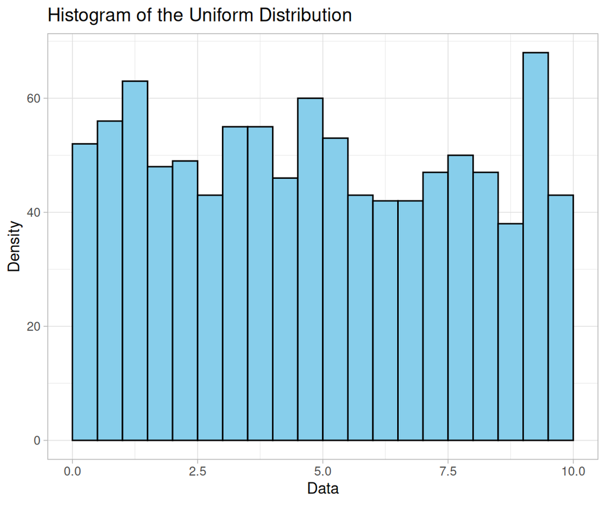

## Example 1: The Bootstrap (2/2)

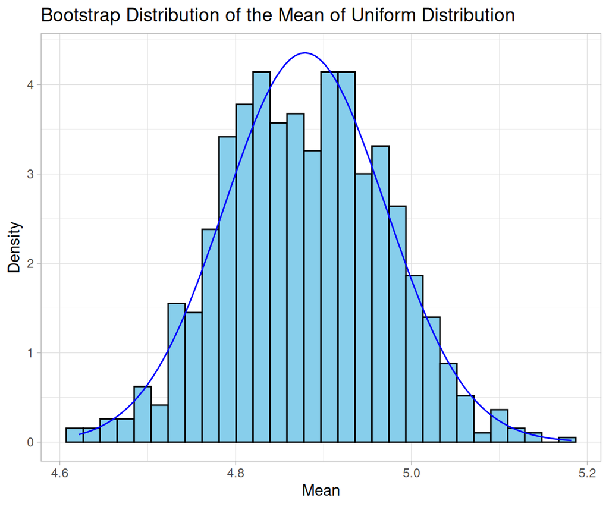

```r
# Bootstrap function
bootstrap_mean <- function(data, B = 1000) {
  n <- length(data) # data is a vector

  mean_values <- replicate(B, {
    indices_sample <- sample(1:n, replace = TRUE)
    mean(data[indices_sample])
  })

  return(mean_values)
}

# Use the bootstrap function
mean_values <- bootstrap_mean(data, B = 1000)

mean_values |>
  as_tibble_col(column_name = "mean_bootstrap") |>
  ggplot() +
  geom_histogram(aes(x = mean_bootstrap, y = after_stat(density)), bins = 30, fill = "skyblue", color = "black") +
  geom_function(fun = dnorm, args = list(mean = mean(mean_values), sd = sd(mean_values)), color = "blue") +
  labs(
    title = "Bootstrap Distribution of the Mean of Uniform Distribution",
    x = "Mean",
    y = "Density"
  ) +
  theme_light()
```

## Example 2: The Bootstrap (1/5)

$$\text{Mean} = \frac{A + B}{2}$$

The calculated mean is 4.9. Of course, the mean from the formula above is simply 5.

## Example 2: The Bootstrap (2/5)

Simulated Data of 100 pairs of returns.

```r
portfolio <- ISLR2::Portfolio
portfolio
```

| X | Y |
| --- | --- |
| -0.89525089 | -0.23492353 |
| -1.56245433 | -0.88517599 |
| -0.41708988 | 0.27188802 |
| 1.04435573 | -0.73419750 |
| -0.31556841 | 0.84198343 |
| -1.73712385 | -2.03719104 |
| 1.96641316 | 1.45295666 |
| 2.15286790 | -0.43413863 |
| -0.08120803 | 1.45080850 |
| -0.89178179 | 0.82101623 |

[output cut: 90 more lines]

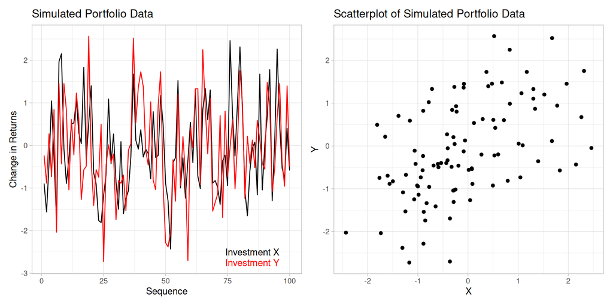

```r
p1 <- portfolio |>
  ggplot() +
  geom_line(aes(x = seq_along(X), y = X)) +
  geom_line(aes(x = seq_along(Y), y = Y), color = "red") +
  labs(
    title = "Simulated Portfolio Data",
    x = "Sequence",
    y = "Change in Returns"
  ) +
  annotate("text", x = 85, y = -2.5, label = "Investment X", color = "black") +
  annotate("text", x = 85, y = -2.75, label = "Investment Y", color = "red") +
  theme_light()

p2 <- portfolio |>
  ggplot() +
  geom_point(aes(x = X, y = Y)) +
  labs(
    title = "Scatterplot of Simulated Portfolio Data",
    x = "X",
    y = "Y"
  ) +
  theme_light()

p1 + p2
```

## Example 2: The Bootstrap (3/5)

> . . . we wish to invest a fixed sum of mony in two financial assests that yeild returns of $X$ and $Y$, respectively, where $X$ and $Y$ are random quantities. We will invest a fraction $\alpha$ of our money in $X$ and will invest the remaining $1-\alpha$ in $Y$ . . . we wish to choose $\alpha$ to minimize the total risk, or variance of our investment.

$$\alpha = \frac{\sigma_Y^2 - \sigma_{XY}}{\sigma_X^2 + \sigma_Y^2 - 2\sigma_{XY}}$$

where $\sigma_X^2$ is the variance of $X$, $\sigma_Y^2$ is the variance of $Y$, and $\sigma_{XY}$ is the covariance between $X$ and $Y$.

(We don’t know these values, but can estimate them from the data, so in reality, we have $\hat{\alpha}$.)

## Example 2: The Bootstrap (4/5)

### Using the Bootstrap to estimate the standard error of $\hat{\alpha}$

```r
# Function to calculate alpha
calculate_alpha <- function(data, indices) {
  X <- data$X[indices]
  Y <- data$Y[indices]

  sigma_X <- var(X)
  sigma_Y <- var(Y)
  sigma_XY <- cov(X, Y)

  alpha <- (sigma_Y - sigma_XY) / (sigma_X + sigma_Y - 2 * sigma_XY)
  return(alpha)
}

# Bootstrap function
bootstrap_alpha <- function(data, B = 1000) {
  n <- nrow(data)
  indices <- 1:n

  alpha_values <- replicate(B, {
    indices_sample <- sample(indices, replace = TRUE)
    calculate_alpha(data, indices_sample)
  })

  return(alpha_values)
}

# Example usage
set.seed(42)
alpha_values <- bootstrap_alpha(portfolio, B = 1000)
mean(alpha_values)
```

```
[1] 0.579369
```

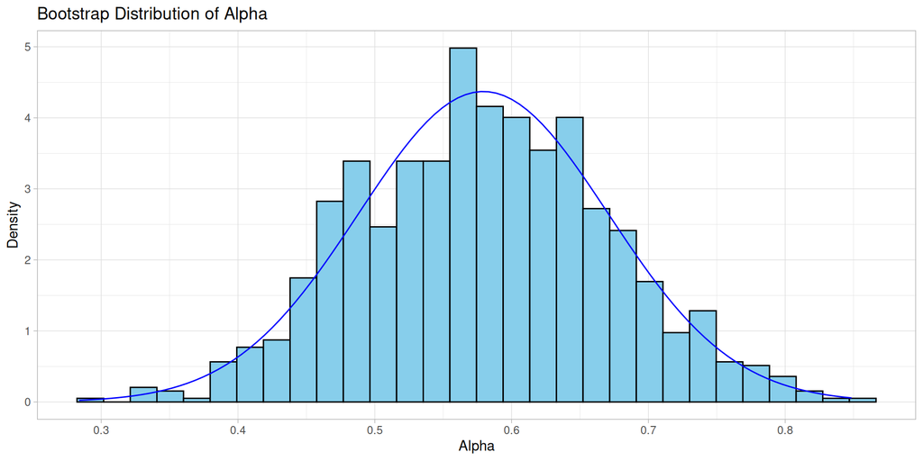

```r
alpha_values |>
  as_tibble_col(column_name = "alpha_bootstrap") |>
  ggplot() +
  geom_histogram(aes(x = alpha_bootstrap, y = after_stat(density)),bins = 30, fill = "skyblue", color = "black") +
  geom_function(fun = dnorm, args = list(mean = mean(alpha_values), sd = sd(alpha_values)), color = "blue") +
  labs(
    title = "Bootstrap Distribution of Alpha",
    x = "Alpha",
    y = "Density"
  ) +
  theme_light()
```

## Example 2: The Bootstrap (5/5)

### Estimate the uncertainty in $\hat{\alpha}$

```r
alpha_values |>
  as_tibble_col(column_name = "alpha_bootstrap") |>
  summarise(
    Mean = mean(alpha_bootstrap),
    SD = sd(alpha_bootstrap),
    SE = sd(alpha_bootstrap) / sqrt(length(alpha_bootstrap)),
    UCI_95 = Mean + SE*qt(c(0.975), length(alpha_bootstrap) - 1),
    LCI_95 = Mean - SE*qt(0.975, length(alpha_values) - 1)
  )
```

| Mean | SD | SE | UCI_95 | LCI_95 |
| --- | --- | --- | --- | --- |
| 0.579369 | 0.09127723 | 0.00288644 | 0.5850332 | 0.5737048 |

# End of Module 8

## References

Quinlan, R. 1993. *Auto MPG*. UCI Machine Learning Repository.